# Week 4: MVPA: Identification & Fit

EDEP 625 Structural Equation Modeling

Susanne DeVore, PhD

2026-10-14

# Agenda

- Review
- Recursive & Non-recursive models
- Degrees of Freedom: Review & in SEM
- Identification & Degrees of Freedom in SEM
- Other Assumptions
- Model-level Fit & Comparing models
- Rlab: Lavaan Package

# Review

- Lamaku > Quiz > W4

Answer the question. 3 minute time limit

# Recursive & Nonrecursive models

## Recursive

- Causal/predictive direction Flows in one direction;
- disturbance terms between variables with direct causal path are not correlated
  - no hidden shared causes of unexplained variance.

## Nonrecursive

- Causal/predictive direction can flow in either direction

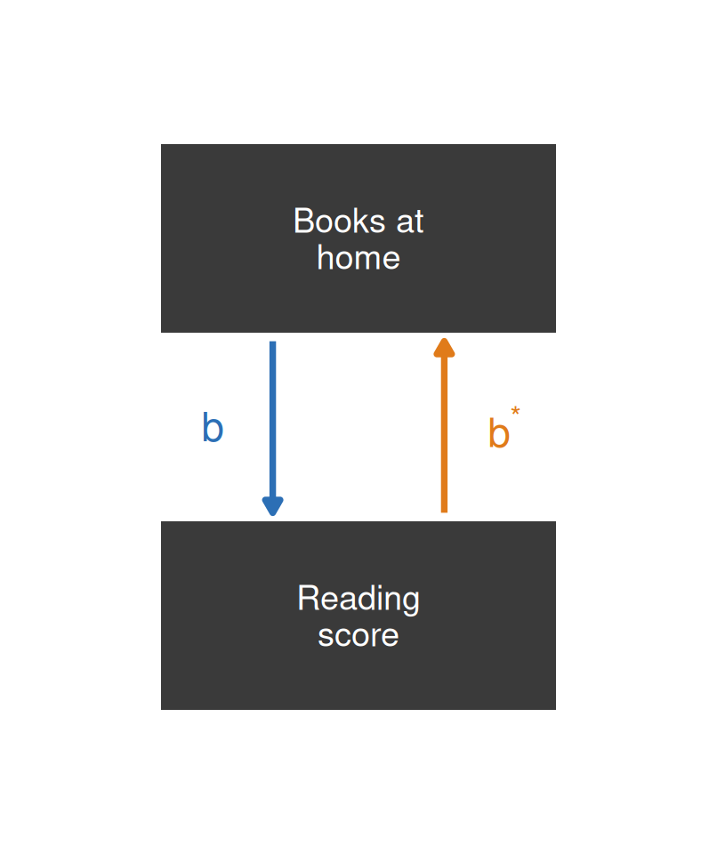

# Degrees of Freedom

## DF in Regression

How do we calculate DF in Regression models?

## DF in SEM

$$df = \underbrace{\text{information}}_{\color{#C81E7A}{\text{n variances/covariances}}} - \underbrace{\text{constraints}}_{\text{n parameters}}$$

## SEM information available

- n variances & covariances in the matrix
- Information $= \dfrac{p(p+1)}{2}$

$$\begin{array}{c|ccc}
& \text{Parent Ed} & \text{Books} & \text{Reading} \\ \hline
\text{Parent Ed} & \sigma^2_{P} & & \\
\text{Books} & \sigma_{PB} & \sigma^2_{B} & \\
\text{Reading} & \sigma_{PR} & \sigma_{BR} & \sigma^2_{R}
\end{array}$$

## DF Parameters

- path coefficients,
- variances of exogenous variables,
- disturbance of endogenous variables,
- Covariances among exogenous variables

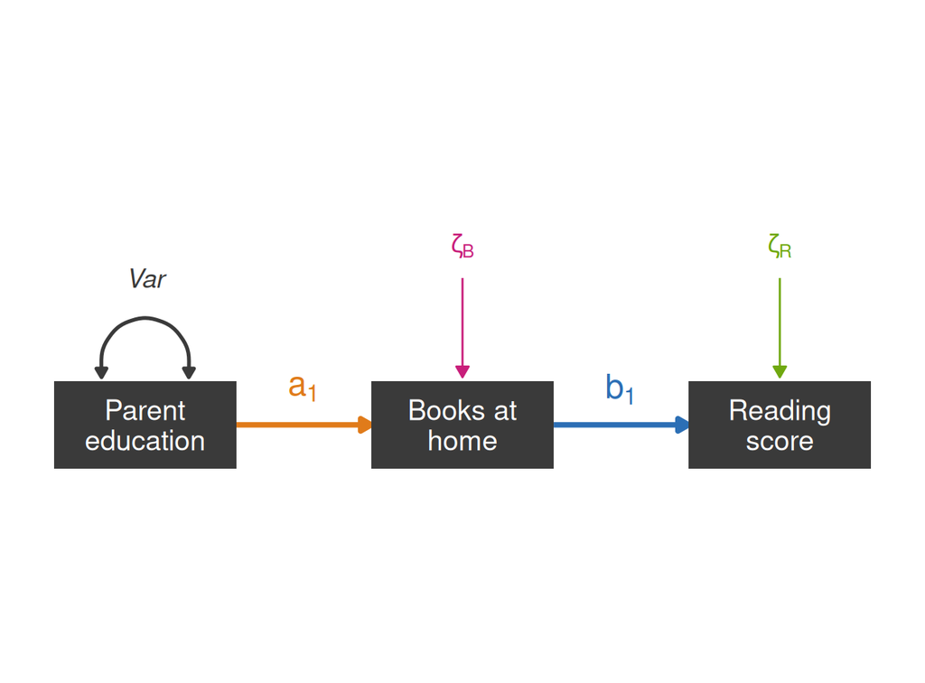

Parameters: a1, b1, var(parent ed), Disturbance of books, disturbance of reading score

## Putting it together

$$df = \underbrace{\text{information}}_{\text{n variances/covariances}} - \underbrace{\text{constraints}}_{\text{n parameters}}$$

$$df = \dfrac{p(p+1)}{2} - q$$

- p: n variables
- q: n parameters to be estimated

$$df = \left(\dfrac{3(4)}{2}\right) - 5 = 1$$

# Identification

Algebraic Illustration:

- Treat A & B as parameters to estimate.
- Treat Outcome as a piece of information (cases)

## Under-Identification

**Algebra**

Solve Example 1:

$$A + B = 6$$

## Under-identification Summary

$$df < 0$$

- Infinite correct solutions
- No way to select a single solution over others

## Over-identification

Solve Example 2:

$$\begin{aligned}
A + B &= 6 \\
2A + B &= 10 \\
3A + B &= 12
\end{aligned}$$

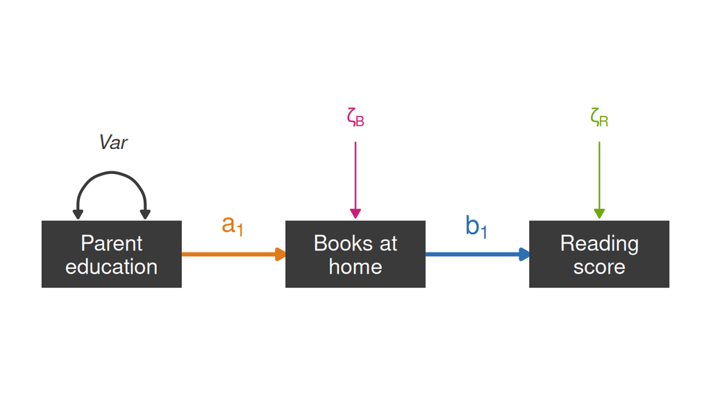

$$\begin{array}{c|ccc}
& \text{Parent Ed} & \text{Books} & \text{Reading} \\ \hline
\text{Parent Ed} & \sigma^2_{P} & & \\
\text{Books} & \sigma_{PB} & \sigma^2_{B} & \\
\text{Reading} & \sigma_{PR} & \sigma_{BR} & \sigma^2_{R}
\end{array}$$

## Over-identification Summary

$$df > 0$$

More pieces of information than parameters

- no perfect solution that satisfies all equations
- Add a criterion: get as close as possible to solving all three (OLS/ML)

## Just-identification

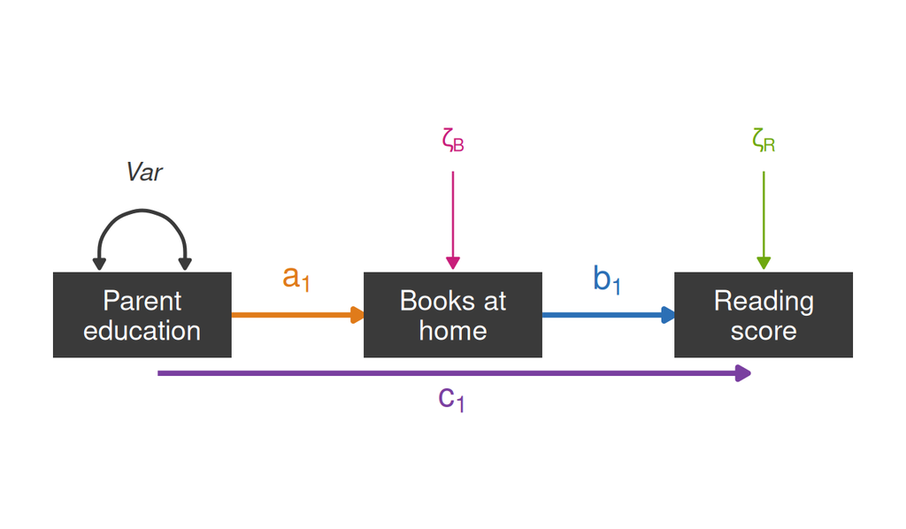

$$\small
\begin{array}{c|ccc}
& \text{Parent Ed} & \text{Books} & \text{Reading} \\ \hline
\text{Parent Ed} & \sigma^2_{P} & & \\
\text{Books} & \sigma_{PB} & \sigma^2_{B} & \\
\text{Reading} & \sigma_{PR} & \sigma_{BR} & \sigma^2_{R}
\end{array}$$

## Just-identified Summary

$$df = 0$$

- Always fits the data perfectly, regardless of whether the causal structure you specified is actually correct
- Not falsifiable

## Pause & Recap

- How do degrees of freedom differ between Regression & SEM?
- How are degrees of freedom used to determine how a model is identified?

# MVPA Assumptions

## Correct Specification

## Identification

## Multicollinearity

Solve Example 4:

$$\begin{aligned}
A + B &= 6 \\
3A + 3B &= 18
\end{aligned}$$

## Sample Size

- Adequate sample size. ~20 cases per parameter.

## Additional Assumptions you can adjust for

- Multivariate normality > required for ML; other estimators can handle violations
- Continuous predictors > Ordinal can be set in Lavaan
- Linearity: Ways to handle non-linear relationships
- Uncorrelated disturbances: Applies only to recursive models

## Pause & Recap

- What assumptions should be met or adjusted for for MVPA?
- What assumptions may be of concern in your data and for your mini project?

# Model Fit

## Null Hypothesis in Regression

## Null hypothesis in SEM 🤸

H0: The model-implied covariance matrix equals the observed covariance matrix

H1: The model-implied covariance matrix does not equal the observed covariance matrix

Rejecting the null means the model we specified is not well-aligned to observed data (evidence AGAINST our hypothesis)

## Key fit indices: Model χ²

Model χ² (chi-square): If model-implied cov matrix differs significantly from observed.

- Significant: reject the null (hypothesis not supported)
- Non-significant: Fail to rejecct the null (hypothesis supported)
- Sensitive to sample size.

## Key fit indices: CFI

CFI (Comparative Fit Index): Uses a baseline model

- Creates a baseline model in which nothing is related
- Determines How much better your model is than assuming nothing is related.
- 0-1 range; higher is better; >= .95 indicates good fit; >= .9 is acceptable

## Key fit indices: SRMR

SRMR (Standardized Root Mean Square Residual)

- Average size of the differences between the observed and model-predicted correlations
- Standardized so it’s comparable across variables.
- Lower is better; ≤ .08 indicates good fit

## Key fit indices: RMSEA

RMSEA (Root Mean Square Error of Approximation)

- Error per degree of freedom
- “how far off is the model, adjusting for how simple or complex it is.”
- Lower is better ≤ .05 indicates good fit; .05–.08 is acceptable; ≥ .10 indicates poor fit

## Key Fit Indices: AIC/BIC

Useful for model comparison

- How well a model fits considering how complex it is using −2(log-likelihood).

Penalizes for complexity:

- AIC: Fixed penalty based on number of parameters
- BIC: Penalty for extra parameters grows with sample size

# Models

Q0: Does parent education relate to reading through the number of books in the home.

# Model 0 Diagram

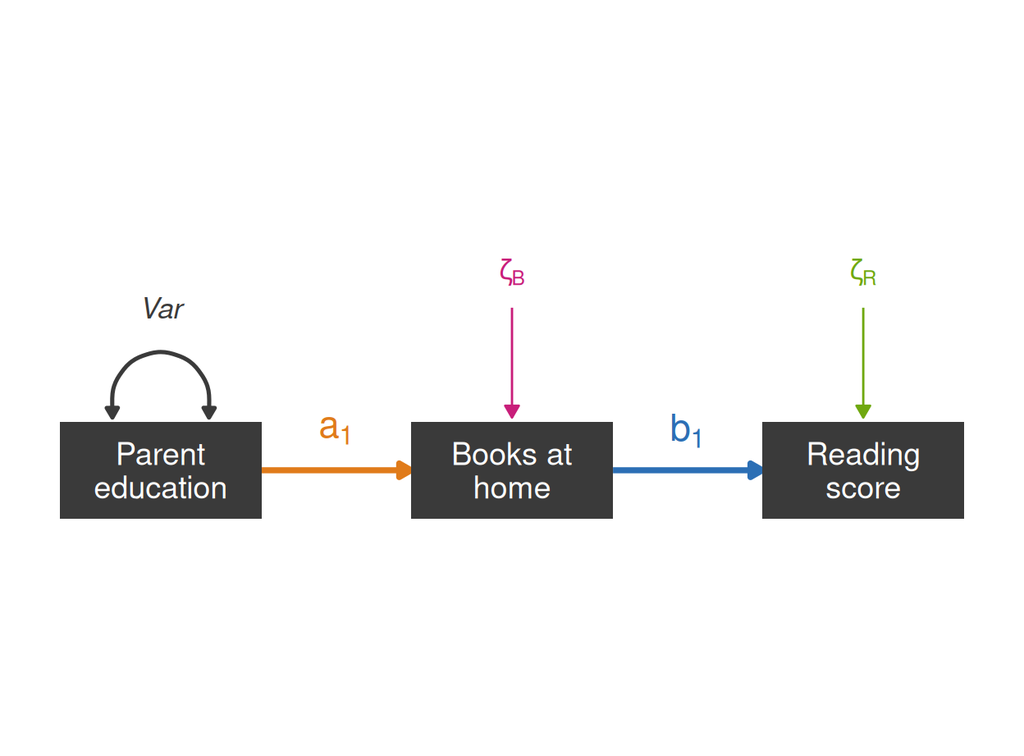

- What theoretical claims does this model make?
- How many degrees of freedom?
- How to describe its identification?

## Model 0 Results

$$\text{Parent Ed} \;\rightarrow\; \text{Books at home} \;\rightarrow\; \text{Reading}$$

| Index | Value | Good fit |
| --- | --- | --- |
| χ² (df) | 12.7 (1), p < .001 | p > .05 |
| CFI | 0.989 | ≥ .95 |
| RMSEA [90% CI] | 0.054 [0.030, 0.082] | ≤ .06 |
| SRMR | 0.020 | ≤ .08 |

# Model Comparison

Rules:

- Same variables
- Same sample
- Same estimator
- Nested structure: One model’s parameter space must be a subset of the other’s, achieved by
  - Fixing one or more parameters to a specific value (usually zero)
  - Constraining two or more parameters to be equal to each other

# Model Comparison Example

RQ: Does parent education relate to students’ reading achievement only through the number of books in the home or does access to technology serve as an additional mediating pathway?

1. Develop a model with only books as a mediator
2. Develop a model with both books and technology as a mediator
3. Compare the two models.

## Model 1

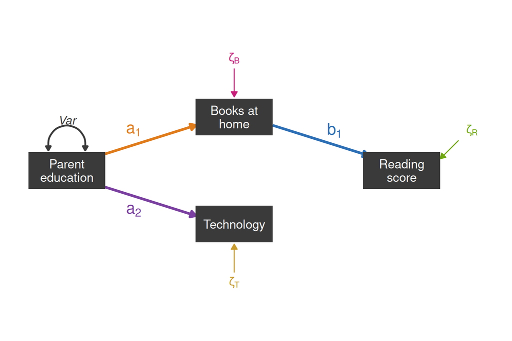

- What theoretical claims does this model make?
- How many degrees of freedom?
- How to describe its identification?

## How well does the model fit the data?

| Index | Value | Good fit |
| --- | --- | --- |
| χ² (df) | 240.7 (3), p < .001 | p > .05 |
| CFI | 0.816 | ≥ .95 |
| RMSEA [90% CI] | 0.154 [0.138, 0.171] | ≤ .06 |
| SRMR | 0.085 | ≤ .08 |

## Model 2

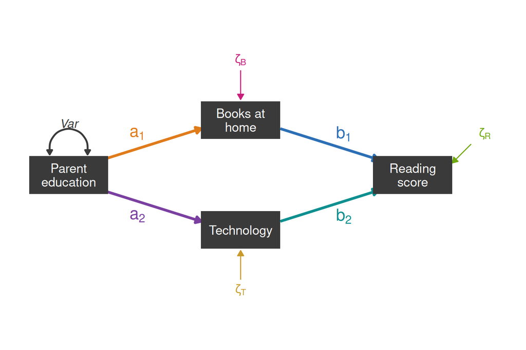

- What theoretical claims does this make?
- How many degrees of freedom?
- How to describe its identification?

## How well does model 2 fit the data?

[output not shown]

## Model comparison:

Does adding the technology -> reading path actually improve the model?

[output not shown]

| Model | df | AIC | BIC |
| --- | --- | --- | --- |
| M1: books-only | 3 | 68560.69 | 68598.09 |
| M2: books + tech | 2 | 68562.60 | 68606.24 |

# Mini Project Checkin:

- You should have preliminary ideas about how to specify a model using your data
- You should be able to run at least a draft version of your own model with your own data
- You should understand if your draft model is a good fit.

# R Lab:

1. Run: W04 Lab: Model Fit & Comparison
2. Continue to Specify your model in the Lavaan (or other) GUI.
- Start your own qmd or rmd file for your mini project
- use the code provided & the code from Lavaan GUI to start building your model
- Run at least a draft version of your model today.

# Up Next:

Interpreting the models

Prep: Lavaan package exploration

- What arguments are relevant to your project/data?
- Use AI to help interpret tech writing into less technical language.